# 立地適正化計画区域内の地価の可視化

富山市の例

[岩田真一郎](https://shinichiro-iwata.github.io/)（[神奈川大学経済学部](https://www.econ.kanagawa-u.ac.jp/)）

2022-06-15

# 目的

国土数値情報の立地適正化計画区域（ポリゴン）と地価公示（ポイント）を利用して地価水準や地価変化率を可視化．

- 低密度化により都市経営が困難になっている自治体が存在．そこで↓
- **特定区域への立地誘導**：医療・福祉施設，商業施設を拠点地域である都市機能誘導区域へ，住居を公共交通沿線の居住誘導区域へ集約する**『コンパクト・プラス・ネットワーク』**の発想で持続可能な都市への変換が求めらている．
  - [立地適正化計画区域](https://www.mlit.go.jp/en/toshi/city_plan/compactcity_network.html)は，[都市計画区域](https://ja.wikipedia.org/wiki/%E9%83%BD%E5%B8%82%E8%A8%88%E7%94%BB%E5%8C%BA%E5%9F%9F)内でなければならない（基本は都市計画区域全体）．立地適正化計画区域内に都市機能誘導区域と居住誘導区域が設定される．
  - 都市再生特別措置法が一部改正（2014年8月施行）され，立地適正化計画制度が創設.

ライブラリ：`sf`，`tidyverse`

```r
library(sf)
library(tidyverse)
```

# 富山のコンパクトシティ政策

- 自治体の中には，立地適正化計画策定前から，誘導区域を指定してきた自治体がある．ここでは，その代表都市である富山市を取り上げることで，地価の時間を通じた変化をとらえる．
  - 富山市では，[富山市中心市街地活性化計画](https://www.city.toyama.toyama.jp/katsuryokutoshisouzoubu/machidukuri/chushinshigaichi.html)（アクセス日：2022/06/09）により中心市街地区域を2007年に，[富山市マスタープラン](https://www.city.toyama.toyama.jp/katsuryokutoshisouzoubu/toshikeikakuka/tosikeikaku/toshimasutapuran.html)（アクセス日：2022/06/15）により公共交通沿線居住推進補助対象地区（公共交通沿線居住推進地区と略す）を2008年に指定し，[コンパクトシティ](https://ja.wikipedia.org/wiki/%E3%82%B3%E3%83%B3%E3%83%91%E3%82%AF%E3%83%88%E3%82%B7%E3%83%86%E3%82%A3)政策を進めてきた．
  - 国際的にも [OECD](https://ja.wikipedia.org/wiki/%E7%B5%8C%E6%B8%88%E5%8D%94%E5%8A%9B%E9%96%8B%E7%99%BA%E6%A9%9F%E6%A7%8B)からメルボルン，バンクーバー，パリ，ポートランドと並んでコンパクトシティ政策を進める先進都市の1つとして富山市の取り組みが紹介されている（OECD，2012）．

区域指定に関わる出来事（富山市）

| 年月日 | 出来事 | 説明 |
| --- | --- | --- |
| 2007年2月8日 | 『中心市街地活性化基本計画』認定 | 中心市街地区域が都市機能誘導区域に該当 |
| 2008年3月26日 | 『都市マスタープラン』策定 | 公共交通沿線居住推進地区が居住誘導区域に該当 |
| 2015年3月14日 | 北陸新幹線開通 |  |
| 2017年3月31日 | 『立地適正化計画』策定 |  |

# 立地適正化計画区域の可視化

**シェープファイルのダウンロード**

- [国土数値情報ダウンロードサービス](https://nlftp.mlit.go.jp/ksj/) > 行政区域（ポリゴン） > 富山県 > 令和3年
- [国土数値情報ダウンロードサービス](https://nlftp.mlit.go.jp/ksj/) > 立地適正化計画区域（ポリゴン） > 富山県 > 世界測地系 > 令和2年
  - ダウンロードしたZIPファイルは同じフォルダー（ディレクトリ）に納め，ZIPファイルを選択 > 右クリック > すべて展開 > 展開先の選択とファイルの選択 > 展開を実行する．展開後は最初にダウンロードしたZIPファイルを削除．
  - 展開したファイルの中身は富山県内の立地適正化計画を策定した市区町村のシェープファイルが含まれている．→富山市（`N03-21_16_210101.shp`）を利用．
  - `read_sf`：データ読込．行政区域を`Toyama_map`，立地適正化計画を`Toyama_compact`と名付ける．

```r
#富山県の地図
Toyama_map<-
  read_sf("N03-20210101_16_GML/N03-20210101_16_GML/N03-21_16_210101.shp")

#富山市の選別
Toyama_map %>%
  filter(N03_004=="富山市") ->
  Toyama_shi_map

#富山市の立地適正化計画地図
Toyama_compact<-
  read_sf("A50-20_16_GML/A50-20_16_GML/16_シェープファイル/A50-20_16201.shp")
```

**区域の識別**

- 区域コード（`A50_006`）を用いて3つの区域を識別．

```r
#立地適正化計画区域
Toyama_compact %>%
  filter(A50_006=="1") ->
  Toyama_shi_plan_area

#居住誘導区域
Toyama_compact %>%
  filter(A50_006=="2") ->
  Toyama_shi_resident_area

#都市機能誘導区域
Toyama_compact %>%
  filter(A50_006=="3") ->
  Toyama_shi_urban_area
```

**可視化**

- 立地適正化計画区域を黄色系，居住誘導区域を緑系，都心機能誘導区域を青系で示す．

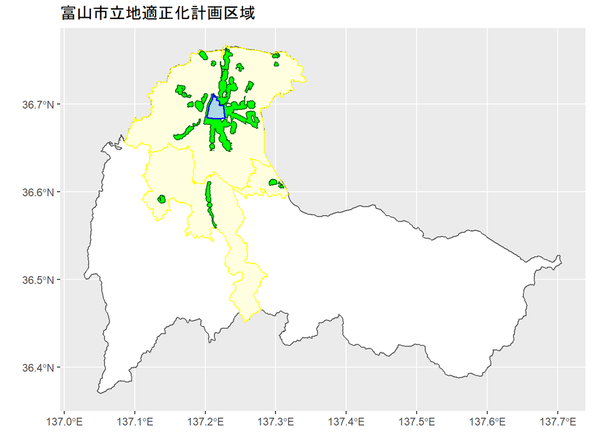

```r
ggplot()+
  geom_sf(data=Toyama_shi_map, fill="white")+
  geom_sf(data=Toyama_shi_plan_area, fill="light yellow", color="yellow")+
  geom_sf(data=Toyama_shi_resident_area, fill="green", color="dark green")+
  geom_sf(data=Toyama_shi_urban_area, fill="light blue", color="blue", size=0.6)+
  ggtitle("富山市立地適正化計画区域")
```

# 地価の可視化

**シェープファイルのダウンロード**

- [国土数値情報ダウンロードサービス](https://nlftp.mlit.go.jp/ksj/) > 地価公示（ポイント） > 富山県 > 「富山県」データのダウンロード > 世界測地系 令和4年 - このデータの便利なところは最新の地価だでけはなく，過去の地価も記録しているところ．
- `Toyama_lp`と名付ける．今回は富山市の地価だけを使うため，富山市を抜き出し，`Toyama_shi_lp`と名付ける．

```r
#富山県の地価のポイント地図
Toyama_lp<-
  read_sf('L01-22_16_GML/L01-22_16.shp')

#富山市の地価の選別
Toyama_lp %>%
  filter(L01_022=="16201") ->
  Toyama_shi_lp
```

**2022年の地価の可視化**

富山市の地図に地価の地図を重ねる．地図上に鉄道（ライン）を示すため，シェープファイルをダウンロード．

- [国土数値情報ダウンロードサービス](https://nlftp.mlit.go.jp/ksj/) > 鉄道（ライン） > 全国 > 世界測地系 > 令和2年
  - 鉄道データは全国のみ．
  - `railway20`と名付ける．
  - パイプ演算子（`%>%`）を使い，路線名（鉄道路線の名称，`N02_003`）の「北陸新幹線」を抜き出し`Hokuriku_shinkansen`と名付ける．

```r
#2020年の鉄道路線図
railway20<-
  read_sf("N02-20_GML/N02-20_GML/N02-20_RailroadSection.shp")

#新幹線の選別
railway20 %>%
  filter(N02_003=="北陸新幹線")->
  Hokuriku_shinkansen
```

地価公示ポイントに色をつけるために，`geom_point()`と`aes(fill)`を利用 ．これを活かすために，地価公示ポイント（x軸が経度，y軸が緯度）の変数を作成．

- ポイントの枠を黒にしたいため．

```r
mutate(Toyama_shi_lp,
       x=st_coordinates(geometry)[,1],
       y=st_coordinates(geometry)[,2]) ->
  Toyama_shi_lp
```

- 地価は高い値が前面になるように指示（`arrange`）．
  - 地価公示ポイントの形状を指示：枠と枠内の色を変えるため，`shape`の`21`（円）を選び，枠を黒，枠内は`scale_fill_distiller`で地価の水準に応じて色を付ける．
    - その他の形状：[shape](https://ggplot2.tidyverse.org/articles/ggplot2-specs.html#sec:shape-spec)参照．
  - 北陸新幹線の線路（`linetype`）の形状を`f8`にする．その他の路線の形状は破線（`dashed`）にする．
    - その他の形状：[linetype](https://ggplot2.tidyverse.org/articles/ggplot2-specs.html#lines)参照．
  - `geom_text()`：地図上に文字の挿入を指示．文字の挿入位置を確定するため経度（`x`）と緯度（`y`）を指定．
  - `labs`は判例の表記の変更のために利用．`x=""`，`y=""`を加えないと，横軸と縦軸にそれぞれ`x`，`y`と表記される．

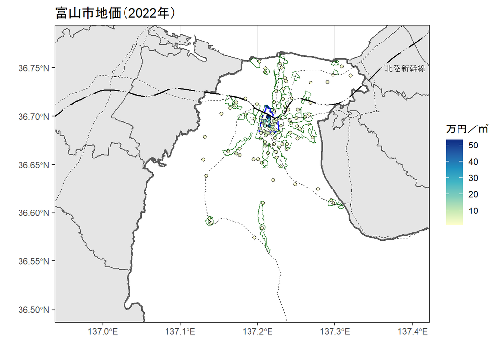

```r
#順番の変更
Toyama_shi_lp %>%
  arrange(L01_006) ->
  Toyama_shi_lp

#可視化
ggplot()+
  geom_sf(data=Toyama_map)+
  geom_sf(data=Toyama_shi_map,
          fill="white", size=0.8)+
  geom_sf(data=Toyama_shi_urban_area,
          fill="NA", color="blue", size=0.6)+
  geom_point(data=Toyama_shi_lp,
             aes(x=x, y=y, fill=L01_006/10000), shape=21)+
  scale_fill_distiller(palette="YlGnBu", direction=1)+
  geom_sf(data=Toyama_shi_resident_area,
          fill="NA", color="dark green", size=0.2)+
  geom_sf(data=railway20, size=0.2,
          linetype="dashed")+
  geom_sf(data=Hokuriku_shinkansen, size=0.55,
          linetype="f8")+
  geom_text(aes(x=137.39, y=36.75), size=3,
              label="北陸新幹線")+
  labs(fill="万円／㎡", x="", y="")+
  ggtitle("富山市地価（2022年）")+
  coord_sf(xlim= c(136.96, 137.4), ylim=c(36.5, 36.78))+
  theme_bw()
```

# 地価変化率の可視化

**地価変化率の作成**

[4 ポイントデータによる地価の可視化](https://shinichiro-iwata.github.io/geospatial-data-visualization/point-data-visualization.html)を参考に，地価変化率を作成．

- ここでは，1997－2007年（中心市街地活性化基本計画認定前），2007年ー2017年（中心市街地活性化基本計画認定後），2017年ー2022年（中心市街地活性化基本計画認定後＋立地適正化計画策定後）の地価変化率を可視化．

```r
#調査時に地価公示ポイントがなかったポイントの地価を0に指示
#今回利用した最新の2022年はすべて調査されている．
#1997年
Toyama_shi_lp %>%
  mutate(L01_075=na_if(L01_075, 0)) ->
  Toyama_shi_lp
#2007年
Toyama_shi_lp %>%
  mutate(L01_085=na_if(L01_085, 0)) ->
  Toyama_shi_lp
#2017年
Toyama_shi_lp %>%
  mutate(L01_095=na_if(L01_095, 0)) ->
  Toyama_shi_lp

#地価変化率の追加
#1997年－2007年
Toyama_shi_lp %>%
  mutate(lp_rate1=((L01_085-L01_075)/L01_075)*100) ->
  Toyama_shi_lp
#2007年－2017年
Toyama_shi_lp %>%
  mutate(lp_rate2=((L01_095-L01_085)/L01_085)*100) ->
  Toyama_shi_lp
#2017年－2022年
Toyama_shi_lp %>%
  mutate(lp_rate3=((L01_006-L01_095)/L01_095)*100) ->
  Toyama_shi_lp

#地価変化率の欠損値NAの列をデータから削除(NAを含まないデータ作成)
#1997年－2007年
Toyama_shi_lp %>%
  filter(!is.na(lp_rate1)) ->
  Toyama_shi_lp1
#2007年－2017年
Toyama_shi_lp %>%
  filter(!is.na(lp_rate2)) ->
  Toyama_shi_lp2
#2017年－2022年
Toyama_shi_lp %>%
  filter(!is.na(lp_rate3)) ->
  Toyama_shi_lp3
```

**鉄道**

2007年（平成19年）時点と2017（平成29年）年時点の鉄道（ライン）を[国土数値情報ダウンロードサービス](https://nlftp.mlit.go.jp/ksj/)からダウンロードし，`railway07`と`railway17`と名付ける．

- 2007年は`crs="WGS84"`が必要．
- 2017 年は日本語文字化けを防ぐ必要（`options = c("encoding=CP932")`）．

```r
#2007年の鉄道路線図
railway07<-
  read_sf("N02-07_GML/N02-07-g_RailroadSection.shp",
                   crs="WGS84")

#2017年の鉄道路線図
railway17<-
  read_sf("N02-17_GML/N02-17_GML/N02-17_RailroadSection.shp",
           options = c("encoding=CP932"))

#北陸新幹線（2015年開通）の選別
railway17 %>%
  filter(N02_003=="北陸新幹線")->
  Hokuriku_shinkansen17
```

**地価変化率の可視化**

コードは1997－2007年（中心市街地活性化基本計画認定前）だけを示す．その後の2枚の地図はコードが重複する箇所が多いため省略．

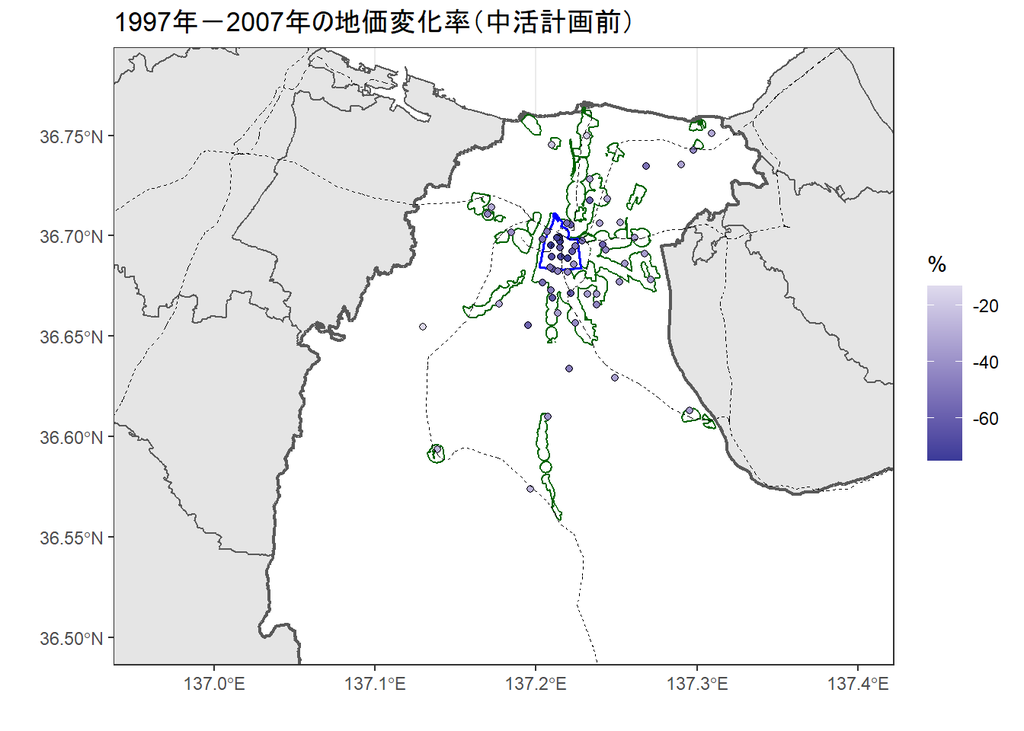

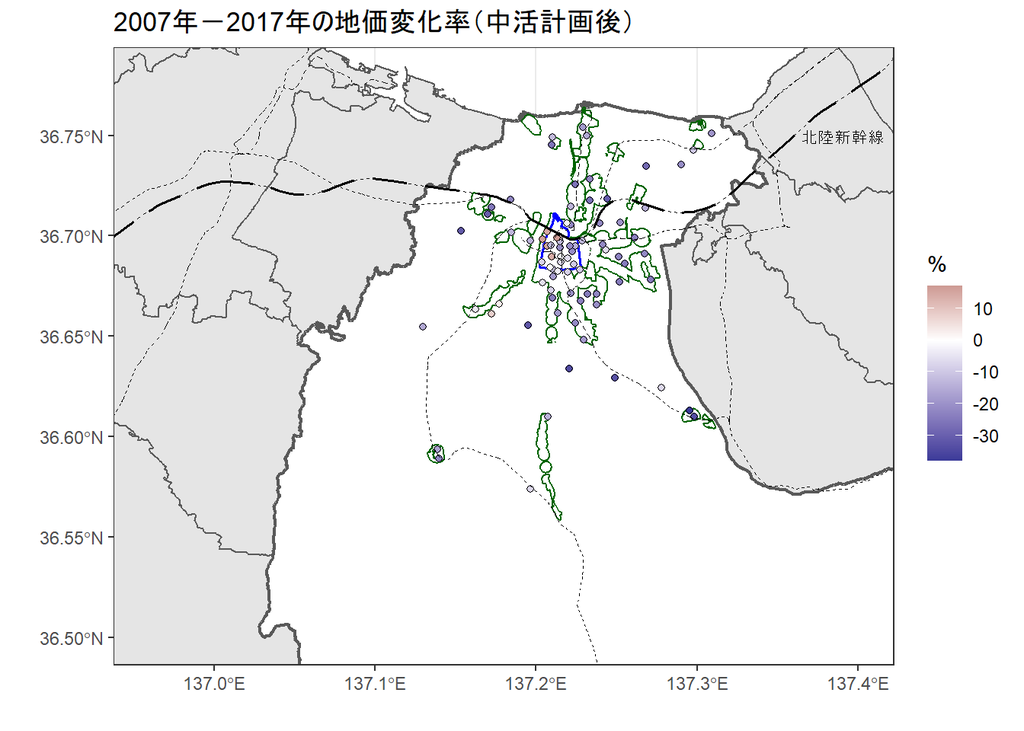

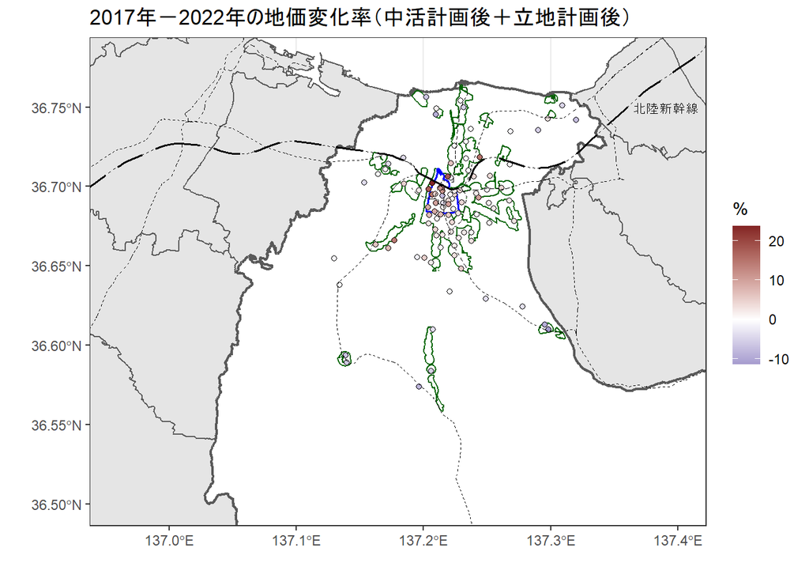

```r
#muted()利用
library(scales)

#可視化
ggplot()+
  geom_sf(data=Toyama_map)+
  geom_sf(data=Toyama_shi_map, fill="white", size=0.8)+
  geom_sf(data=Toyama_shi_resident_area,
          fill="NA", color="dark green")+
  geom_sf(data=Toyama_shi_urban_area,
          fill="NA", color="blue", size=0.6)+
  geom_point(data=Toyama_shi_lp1,
             aes(x=x, y=y, fill=lp_rate1), shape=21)+
  scale_fill_gradient2(low=muted("blue"),
                       mid="white",
                       high=muted("red"))+
  geom_sf(data=railway07, size=0.2,
          linetype="dashed")+
  coord_sf(xlim= c(136.96, 137.4), ylim=c(36.5, 36.78))+
  labs(fill="%", x="", y="")+
  ggtitle("1997年－2007年の地価変化率（中活計画前）")+
  theme_bw()
```

**参考文献**

- OECD, (2012). *Compact City Policies: A Comparative Assessment*, OECD Green Growth Studies, OECD Publishing, Paris.

**Rによる地理空間データの可視化**

- チュートリアル[ホーム](https://shinichiro-iwata.github.io/geospatial-data-visualization/)